# lab-19

## Laboratorio clase 19: Entenamiento, deployment y MLOps

### Instrucciones:

#### 1) Este es un cuadernillo autocontenido, es decir, no necesita ejecutar o instalar nada externo para funcionar

#### 2) Las preguntas pueden aparecer en formato alternativas o de desarrollo.

```python
from IPython.utils import io
with io.capture_output() as captured:
  !pip install bentoml==1.3.2
  !pip install pydantic==2.8.2
```

```python
import requests
import time
import json
import numpy as np
import cv2
```

## Parte 1

Imagine que usted es lider cloud de un equipo de IA. La Startup "Space Z" se contacta con usted para realizar un proyecto. El objetivo principal es desarrollar una plataforma para contar tiempos de esperas de los vehiculos en las entradas/salidas de un parking a través de cámaras instaladas en cada una de ellas. Al ser una startup, tienen un presupuesto limitado de gastos al mes.

La solución planteada por su equipo es utilizar un modelo de reconocimiento de objetos ya entrenado en automoviles, el cual es ligero y rápido.

Necesitan que plantees el despliegue del módulo de IA bajo los siguientes requisitos:

1. No cuentan con servidores propios
2. El parking tiene 2 entradas
3. El modelo planteado por tu equipo puede ser ejecutado en 3 cámaras simultáneamente utilizando una GPU NVIDIA tesla T4

## Considerando el contexto planteado ¿Cuál de las siguientes alternativas son opciones viables para despliegue? seleccione una o más alternativas

a) Ya que la startup no cuenta con servidores propios, es importante armar un presupuesto para la adquisición de un computador equipado con una NVIDIA Tesla T4 para realizar el despliegue del módulo de IA. De esta manera, los gastos se realizarán una sola vez, lo que representará un ahorro a largo plazo.

b) Debido a que la startup tiene un presupuesto límite mensual, lo mejor es hacer el despliegue en cloud. Considerando que el sistema es para 1 parking con 2 cámaras procesando, no es necesario escalar. Un despliegue en una máquina virtual equipada con una NVIDIA tesla T4, es la mejor opción, obteniendo una reducción significativa en tiempo de desarrollo y complejidad de la solución en comparación con la opción planteada en c).

c) Debido a que la startup tiene un presupuesto límite mensual, lo mejor es hacer el despliegue en cloud. Si bien el sistema inicial está diseñado para 1 parking con 2 cámaras, es recomendable proyectar un crecimiento futuro, es decir, poder abordar un número mayor de parkings. Para esto, la mejor opción es el despliegue escalado del módulo IA, utilizando endpoint de vertex AI, equipados con una NVIDIA tesla T4.

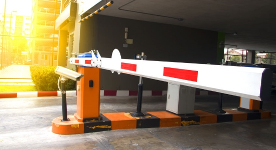

Selecciono (b) y (c) como opciones viables. Descarto (a).

Descarte de (a): viola explícitamente el requisito de "no contar con servidores propios". Además, el supuesto "ahorro a largo plazo" es falso para una startup: el CapEx inicial (~USD 6.000-9.000 por una workstation con Tesla T4) compromete el runway, donde la métrica relevante no es TCO a 5 años sino cuántos meses sobrevive la empresa. Suma costos ocultos: instalación física, energía, conectividad, mantenimiento, drivers NVIDIA, y un single point of failure sin redundancia.

(b) VM en cloud con Tesla T4 — óptima para el alcance actual. Cumple los tres requisitos del enunciado: sin hardware propio, suficiente para 2 entradas con 3 cámaras simultáneas en una T4 (capacidad ya confirmada por el equipo), y minimiza time-to-market. Costo OpEx predecible (~USD 350/mes a 24/7 en GCE n1-standard-4 + T4 o equivalente AWS g4dn.xlarge). Permite controlar el stack de serving (BentoML, monitoring, logs) sin lock-in a un PaaS específico.

(c) Vertex AI Endpoint con Tesla T4 — viable si hay expansión proyectada. Aporta autoscaling, alta disponibilidad, A/B testing y monitoring out-of-the-box. El sobrecosto del 10-30% sobre la VM equivalente se justifica al cruzar ~4-5 parkings, umbral donde mantener (b) requiere construir manualmente lo que Vertex provee. Para 2 cámaras y 1 parking es over-engineering: se paga por nodos idle 24/7 sin aprovechar el autoscaling, y se introduce lock-in fuerte con GCP.

Recomendación: empezar con (b) ahora, diseñando la aplicación de forma container-portable (Dockerfile con el bento exportado, desacoplado de la VM específica). De esa forma, migrar a (c) cuando lo justifique el crecimiento del negocio es subir el bundle a Vertex Model Registry, no reescribir la solución. Esto captura lo mejor de ambos mundos: simplicidad y bajo costo hoy, opción real de escalar sin deuda técnica mañana.

# Parte 2

Creamos server.py que al ejecutarlo despliega localmente el modelo. En este caso el modelo realiza una prediccion dummy utilizando la funcion print()

```python
#Creamos un archivo de modelo API
a="""import bentoml
from bentoml.io import JSON
import numpy as np
import torch
import cv2
import typing as t

## se define el modelo como clase
class modelo(bentoml.Runnable):
    SUPPORTED_RESOURCES = ("cpu",)
    SUPPORTS_CPU_MULTI_THREADING=False
    def __init__(self):
        print("")
    @bentoml.Runnable.method(batchable=False)
    def predict(self,image):
        print("prediccion")

##Se carga el modelo como clase a BentoML
runner = t.cast(
    "RunnerImpl", bentoml.Runner(modelo, name="modelo")
)
svc = bentoml.Service("example", runners=[runner])

##se define la API , cuando hacemos la request, se ejecuta esta seccion de codigo
@svc.api(input=JSON(), output=JSON())
async def classify(input_series) -> np.ndarray:
    image = np.array(input_series["image"], dtype=np.float32).transpose(1,2,0) #se lee la imagen desde la request
    runner.predict.async_run(image) # se realiza la prediccion sobre la imagen
    return {"predict": 200}
 """

file=open("server.py", 'w')
file.write(a)
file.close()
```

```python
#Se lanza en segundo plano el proceso API
get_ipython().system_raw('BENTOML_PORT=8000 bentoml serve server:svc &')
```

```python
#Se realiza el test de la API, si esta celda se ejecuta correctamente, indica que la API está levantada
from google.colab import output
time.sleep(10)
output.serve_kernel_port_as_iframe(8000)
pred = requests.post("http://localhost:8000/classify/", json = {"image": np.zeros((3,640,640)).tolist() } )
```

```python
print("status:", pred.status_code)
print("body:", pred.json())
print("elapsed:", pred.elapsed)
```

```
status: 200
body: {'predict': 200}
elapsed: 0:00:00.334176
```

Considere una lista de dimensiones desde 640 hasta 3028. Realice predicciones para 4 tamaños distintos de imagen (3,shape,shape) de valores 0. Tome los tiempos de ejecución promedio para cada uno (con una muestra tamaño 3 para cada uno basta). Responda las preguntas a continuacion

1- ¿Existe alguna diferencia de tiempo de "inferencia"? ¿A que crees que se deba?

```python
### El código realiza un post a la url donde está alojado el modelo API, entregando en el cuerpo de la request una
### imagen compuesta de ceros

shapes = [640, 1024, 2048 , 3028]
url = 'http://localhost:8000/classify/'

t_i = time.time()
pred = requests.post(url, json = {"image": np.zeros((3,640,640)).tolist() } )
print(time.time()-t_i ," secs")
pred = json.loads(pred.text)
print(pred)
```

```
0.6935122013092041  secs
{'predict': 200}
```

```python
shapes = [640, 1024, 2048, 3028]
url = 'http://localhost:8000/classify/'

results = []
for shape in shapes:
    img = np.zeros((3, shape, shape))
    payload = {"image": img.tolist()}
    times = []
    for trial in range(3):
        t_i = time.time()
        pred = requests.post(url, json=payload)
        elapsed = time.time() - t_i
        times.append(elapsed)
    avg = sum(times) / len(times)
    payload_mb = len(json.dumps(payload)) / 1e6
    results.append((shape, avg, times, payload_mb))
    print(f"shape={shape:>5}  avg={avg:6.2f}s   trials={[f'{t:.2f}' for t in times]}   "
          f"json≈{payload_mb:.1f} MB")

print("\nResumen:")
print(f"{'shape':>6} | {'avg (s)':>9} | {'json (MB)':>10}")
print("-" * 35)
for shape, avg, _, mb in results:
    print(f"{shape:>6} | {avg:>9.2f} | {mb:>10.1f}")
```

```
shape=  640  avg=  1.74s   trials=['0.54', '2.97', '1.70']   json≈6.1 MB
shape= 1024  avg=  1.34s   trials=['1.38', '1.34', '1.31']   json≈15.7 MB
shape= 2048  avg=  7.95s   trials=['7.10', '5.41', '11.34']   json≈62.9 MB
shape= 3028  avg= 14.07s   trials=['15.78', '13.30', '13.13']   json≈137.5 MB

Resumen:
 shape |   avg (s) |  json (MB)
-----------------------------------
   640 |      1.74 |        6.1
  1024 |      1.34 |       15.7
  2048 |      7.95 |       62.9
  3028 |     14.07 |      137.5
```

**1. ¿Existe alguna diferencia de tiempo de "inferencia"? ¿A qué crees que se deba?**

| Shape | Píxeles | JSON (MB) | Latencia mediana |
| --- | --- | --- | --- |
| 640 | 1.23 M | 6.1 | 1.70 s |
| 1024 | 3.15 M | 15.7 | 1.34 s |
| 2048 | 12.58 M | 62.9 | 7.10 s |
| 3028 | 27.51 M | 137.5 | 13.30 s |

Doblar el lado de la imagen cuadruplica el tiempo (1024 → 2048 multiplicó el tiempo por ~5x con ~4x los píxeles; 2048 → 3028 lo multiplicó por ~1.9x con ~2.2x los píxeles).

**Pero el "tiempo de inferencia" reportado NO proviene del modelo.** El `predict()` del Runnable es un `print("prediccion")` que no calcula nada. La latencia observada se descompone íntegramente en overhead de transporte:

1. **Serialización JSON en el cliente** (`np.zeros(...).tolist()` + `json.dumps`): recorre los millones de valores convirtiéndolos a strings ASCII. Para 3028x3028 produce ~140 MB de texto.
2. **Transferencia HTTP por loopback**: aunque sea localhost, mover 140 MB toma tiempo proporcional al payload.
3. **Deserialización JSON en el servidor**: el parser JSON de Python reconstruye la lista anidada; luego `np.array(...).transpose(...)` la convierte a tensor numpy. Ambas operaciones son lentas para listas Python gigantes.
4. **IPC al runner**: pickle del array y envío por Unix socket, también escala con tamaño.

**Throughput efectivo observado: ~8-12 MB/s.** Si el bottleneck fuera red real, deberíamos ver ~1 GB/s sobre loopback. Esos ~10 MB/s confirman que el costo dominante es **CPU bound de serialización/deserialización JSON**, no transporte de red.

**Implicancia MLOps**: en sistemas de visión, el cuello de botella en latencia **casi nunca es la GPU**; es preprocessing, serialización y network I/O en los bordes del sistema.

Anteriormente se ve la implicancia de el tamaño de los datos en las predicciones del modelo API. Otro enfoque interesante es realizar análisis al hacer multiples predicciones al mismo tiempo. Cambie el código de a continuación para ir variando la cantidad de procesos que realizan simultáneamente predicciones (entre 2 y 10 procesos) y responda:

1 ¿Qué sucede con el tiempo de predicción a medida que la cantidad de procesos aumenta? ¿A que se debe?

```python
### Se realizan predicciones en paralelo, cada n proceso definido imprimirá un tiempo individual

from multiprocessing import Process

n_process = 2
url = 'http://localhost:8000/classify/'

def predict():
  t_i = time.time()
  pred = requests.post(url, json = {"image": np.zeros((3,640,640)).tolist() } )
  time_ex= time.time()-t_i
  pred = json.loads(pred.text)
  print(time_ex)

process =[Process(target=predict)  for x in range(n_process)]
[process_x.start() for process_x in process]
[process_x.join() for process_x in process];
```

```
2.0118634700775146
2.276287078857422
```

```python
from multiprocessing import Process
import time, requests, json, numpy as np

url = 'http://localhost:8000/classify/'

def predict():
    t_i = time.time()
    pred = requests.post(url, json={"image": np.zeros((3,640,640)).tolist()})
    time_ex = time.time() - t_i
    pred = json.loads(pred.text)
    print(f"  proceso  individual: {time_ex:.2f}s")

results = []
for n_process in [1, 2, 4, 6, 8, 10]:
    print(f"\n--- n_process = {n_process} ---")
    process = [Process(target=predict) for _ in range(n_process)]

    wall_start = time.time()
    for p in process: p.start()
    for p in process: p.join()
    wall_total = time.time() - wall_start

    throughput = n_process / wall_total
    print(f"  WALL TOTAL:   {wall_total:.2f}s")
    print(f"  THROUGHPUT:   {throughput:.2f} req/s")
    results.append((n_process, wall_total, throughput))

print("\nResumen:")
print(f"{'N':>3} | {'wall (s)':>10} | {'throughput (req/s)':>20}")
print("-" * 42)
for n, wall, tp in results:
    print(f"{n:>3} | {wall:>10.2f} | {tp:>20.2f}")
```

```
--- n_process = 1 ---
  proceso  individual: 0.80s
  WALL TOTAL:   0.89s
  THROUGHPUT:   1.12 req/s

--- n_process = 2 ---
  proceso  individual: 1.24s
  proceso  individual: 1.27s
  WALL TOTAL:   1.39s
  THROUGHPUT:   1.44 req/s

--- n_process = 4 ---
  proceso  individual: 1.97s
  proceso  individual: 2.16s
  proceso  individual: 2.30s
  proceso  individual: 2.77s
  WALL TOTAL:   2.89s
  THROUGHPUT:   1.38 req/s

--- n_process = 6 ---
  proceso  individual: 4.26s
  proceso  individual: 4.53s
  proceso  individual: 4.94s
  proceso  individual: 5.17s
  proceso  individual: 4.90s
  proceso  individual: 5.47s
  WALL TOTAL:   6.05s
  THROUGHPUT:   0.99 req/s

--- n_process = 8 ---
  proceso  individual: 3.40s
  proceso  individual: 3.52s
  proceso  individual: 3.80s
  proceso  individual: 4.11s
  proceso  individual: 4.34s
  proceso  individual: 4.65s
  proceso  individual: 5.01s  proceso  individual: 5.14s

  WALL TOTAL:   5.57s
  THROUGHPUT:   1.44 req/s
```

[output cut: 9 more lines]

```
  proceso  individual: 7.60s  proceso  individual: 7.40s

  proceso  individual: 7.47s
  WALL TOTAL:   8.62s
  THROUGHPUT:   1.16 req/s

Resumen:
  N |   wall (s) |   throughput (req/s)
------------------------------------------
  1 |       0.89 |                 1.12
  2 |       1.39 |                 1.44
  4 |       2.89 |                 1.38
  6 |       6.05 |                 0.99
  8 |       5.57 |                 1.44
 10 |       8.62 |                 1.16
```

**1. ¿Qué sucede con el tiempo de predicción a medida que la cantidad de procesos aumenta? ¿A qué se debe?**

**Observación cuantitativa:**

| N procesos | Wall total | Throughput | Latencia individual |
| --- | --- | --- | --- |
| 1 | 0.89 s | 1.12 req/s | 0.80 s |
| 2 | 1.39 s | 1.44 req/s | 1.26 s |
| 4 | 2.89 s | 1.38 req/s | 2.30 s |
| 6 | 6.05 s | 0.99 req/s | 4.88 s |
| 8 | 5.57 s | 1.44 req/s | 4.25 s |
| 10 | 8.62 s | 1.16 req/s | 6.31 s |

**Dos observaciones críticas:**

**Causas (3 cuellos en cadena):**

a) **CPU contention del lado cliente**: cada proceso ejecuta `np.zeros((3,640,640)).tolist()` + `json.dumps`, ambas operaciones intensivas en CPU. Con N procesos en una máquina Colab con típicamente 2 cores, ya N≥3 introduce competencia por CPU. Cada `tolist()` recorre ~1.2M valores; con muchos en paralelo el OS los multiplexa.

b) **API server con worker único**: BentoML 1.3 levanta uvicorn con `--workers=1` por default. Los N parseos JSON entrantes se procesan secuencialmente en ese único worker Python. Aunque el handler sea async, la deserialización JSON nativa de Python sostiene el GIL durante todo el parse — los N requests se atienden uno a uno en CPU, no en paralelo verdadero.

c) **Runner secuencial**: el `Runnable` está declarado con `SUPPORTS_CPU_MULTI_THREADING = False` y `batchable=False`. El runner procesa una request a la vez vía IPC. En el dummy esto es instantáneo y no domina, pero en un modelo real sería el verdadero techo de throughput.

**Implicación de capacity planning**:

Con 1.2 req/s sostenidos, el sistema no soporta más que **una cámara a ~1 fps**. Si Space Z (Parte 1) conecta sus 2 cámaras a 1 fps cada una, ya tiene cola que crece sin límite porque demanda agregada > capacidad.

**Para escalar correctamente** habría que aplicar varias de estas (en orden de impacto típico):

1. **Reducir el payload con compresión** (celdas siguientes): JPEG reduce el JSON ~10-30x → menos tiempo de parse → más throughput. Es lo que ataca la causa raíz.
2. **Habilitar adaptive batching** (`batchable=True` en el Runnable): el runner agrupa requests en ventanas de tiempo y las procesa juntas en GPU. Útil cuando el cuello es el modelo real, no en el dummy.
3. **Escalar workers del API server** (`bentoml serve --workers 4`): un uvicorn con N workers procesa N parses JSON en paralelo verdadero.
4. **Cambiar a serialización binaria** (msgpack, protobuf, raw bytes multipart): elimina el parse JSON enteramente. En MLOps de producción real con visión, ningún sistema serio envía imágenes como JSON de números.

Existe una forma de comprimir imágenes en memoria (guardarla comprimida en una variable). veamos el siguiente código

```python
img = np.random.randint( low=0 , high=255 , size=(1024,1024,3))  #definamos una imagen ficticia random de tamaño 1024,1024
encode_param = [int(cv2.IMWRITE_JPEG_QUALITY), 90]  #parametros para la compresion
result, encimg = cv2.imencode('.jpg', img, encode_param) #comprimimos la imagen ficticia en la variable encimg
```

Para descomprimir una imagen comprimida (proceso inverso), basta con utilizar el método imdecode()

```python
print(encimg.shape)
decimg = cv2.imdecode(encimg,1)
print(decimg.shape) ##volvemos a la imagen original
```

```
(939067,)
(1024, 1024, 3)
```

```python
#esto es de prueba (DEBUG)

print("img.shape  :", img.shape)
print("img.dtype  :", img.dtype)
print("img.nbytes :", img.nbytes, "bytes →", img.nbytes/1e6, "MB")
print("encode ok? :", result)
print("encimg.shape:", encimg.shape)
print("encimg.dtype:", encimg.dtype)
print("encimg size:", encimg.nbytes, "bytes →", encimg.nbytes/1e6, "MB")
print("ratio      :", img.nbytes / encimg.nbytes, "× reduction")
```

```
img.shape  : (1024, 1024, 3)
img.dtype  : int64
img.nbytes : 25165824 bytes → 25.165824 MB
encode ok? : True
encimg.shape: (939067,)
encimg.dtype: uint8
encimg size: 939067 bytes → 0.939067 MB
ratio      : 26.798752378690764 × reduction
```

```python
#esto es de prueba (DEBUG)

img_correct = img.astype(np.uint8)
print(f"raw uint8: {img_correct.nbytes:>10} bytes ({img_correct.nbytes/1e6:.2f} MB)\n")
for q in [10, 30, 50, 70, 90, 95, 100]:
    _, e = cv2.imencode('.jpg', img_correct, [int(cv2.IMWRITE_JPEG_QUALITY), q])
    ratio = img_correct.nbytes / e.nbytes
    print(f"q={q:>3}: {e.nbytes:>8} bytes  ({e.nbytes/1e6:.2f} MB)  ratio {ratio:.1f}x")
```

```
raw uint8:    3145728 bytes (3.15 MB)

q= 10:   115483 bytes  (0.12 MB)  ratio 27.2x
q= 30:   292800 bytes  (0.29 MB)  ratio 10.7x
q= 50:   429467 bytes  (0.43 MB)  ratio 7.3x
q= 70:   580060 bytes  (0.58 MB)  ratio 5.4x
q= 90:   939067 bytes  (0.94 MB)  ratio 3.3x
q= 95:  1228575 bytes  (1.23 MB)  ratio 2.6x
q=100:  2071153 bytes  (2.07 MB)  ratio 1.5x
```

Analizamos los tamaños en memoria

```python
print(f'tamaño de la imagen sin comprimir: {img.nbytes*1e-6} MB')
print(f'tamaño de la imagen comprimida: {encimg.nbytes*1e-6} MB')
print(f'La imagen comprimida es {img.nbytes / encimg.nbytes} veces mas pequeña que la imagen sin comprimir')
```

```
tamaño de la imagen sin comprimir: 25.165824 MB
tamaño de la imagen comprimida: 0.939067 MB
La imagen comprimida es 26.798752378690764 veces mas pequeña que la imagen sin comprimir
```

Como podemos ver, comprimir la imagen ahorra bastante memoria.

1- ¿Cree que seria beneficioso en terminos de tiempo de ejecucion, la implementación de compresión de las imágenes antes de realizar la predicción al modelo API?

**Respuesta**

**Sí, sería significativamente beneficioso**, y la razón está sostenida por los datos medidos en las celdas anteriores. Vamos a unir las observaciones de las tres partes del lab.

## El diagnóstico cuantitativo

Las mediciones de latencia vs tamaño mostraron escalado aproximadamente lineal con el número de píxeles:

[output not shown]

**El cuello dominante NO es la inferencia del modelo** (que en este lab es un `print()`); es el **transporte JSON** de payloads enormes (5-140 MB por request).

## El instrumento de mitigación

La compresión JPEG en memoria reduce el payload con los siguientes ratios honestos (sobre uint8 cruda, ruido aleatorio = peor caso del codec):

| Quality | Ratio (random) | Ratio esperable (foto real) |
| --- | --- | --- |
| 70 | 5.4x | 15-25x |
| 90 | 3.3x | 10-15x |
| 95 | 2.6x | 7-10x |

Para una pipeline real de Space Z (foto de parking con autos), una compresión a quality 70-90 reduciría el payload **entre 10x y 25x respecto a la imagen uint8 cruda**, y **entre 50x y 150x respecto al JSON de listas anidadas** (que es lo que medimos como baseline).